# Random Forest for site survey

Claudine Gravel-Miguel

3/21/2022

In this document, I train a random forest model using Spanish archaeological sites to identify where sites might be in Liguria.

As predictors, I use the popularity map created by the AB_LCP, a DEM, the distance from rivers and coast, and the geology at documented caves.

# Spanish sites during the transition

For the grant proposal, I already cleaned the Vermeersch v27 database to focus on sites with reliable radiocarbon dates, and I calibrated them. So, here I simply imported it and focused on the Spanish sites of the right time period.

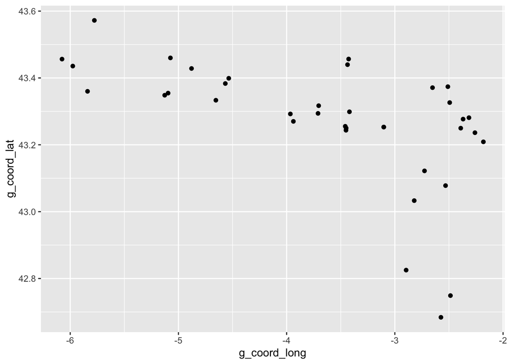

# Known Italian sites during the transition

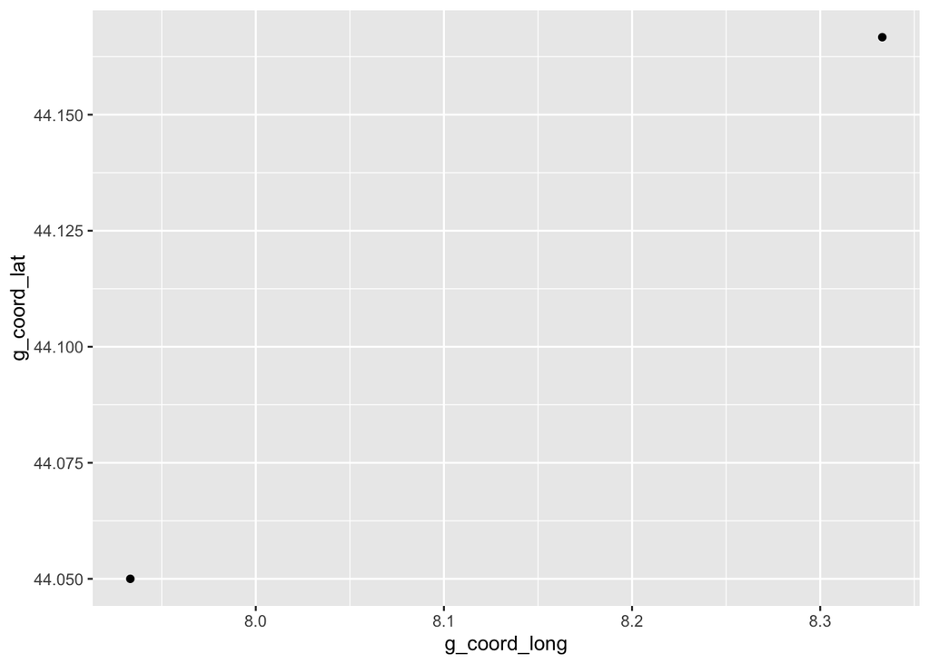

# Importing caves shapefiles

I obtained the location of caves from the OpenStreetMap project. I am first cleaning the datasets and formatting it in the same way as the archaeological sites datasets. Then, I will join the two so that caves with archaeology have the MesoArch variable as TRUE and the caves who do not (or for which we do not have known presence) will have the variable as FALSE.

To make sure that my join actually links the same caves even if there are typos, I’m simplifying the site names and using those names for the join.

# Import the predictor maps

## Import the mobility maps

In this section, I import the rasters created by the AB-LCP model and compile their results by adding their values (sum, ignoring NA).

This map show the normalized summed mobility in Spain.

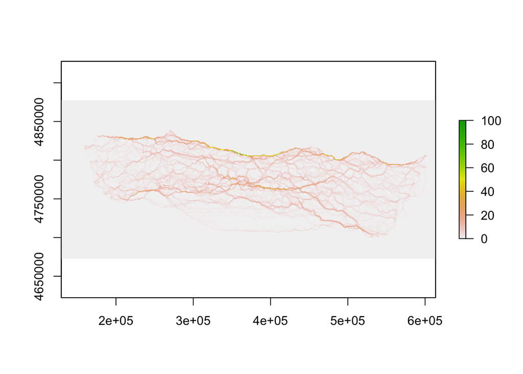

This map show the normalized summed mobility in Liguria.

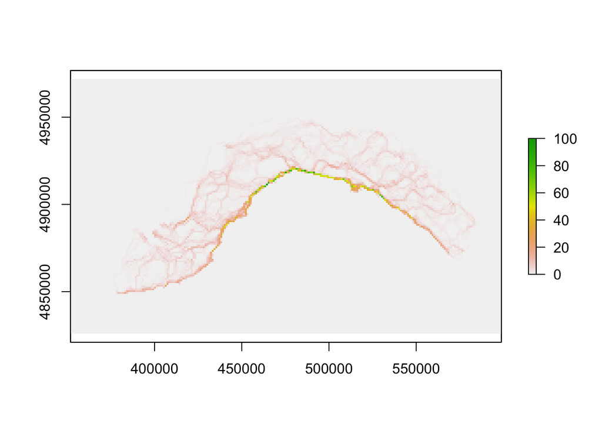

Those are then reprpjected to LatLong to fit the rest of the data.

## Import the other predictors

Importing the maps of elevation, slope, distance from rivers, distance from coast, viewshed from summits, and geology. Formatting those to make sure that they are in the correct projection (Lat Long).

# Extracting raster values at caves’ locations

Here, we extract the values from the imported rasters (predictors) using the coordinates of the caves cleaned up earlier.

For mobility and visibility from summit, the etxracting takes the max value within a 1 km radius around the point. For all other values, the value is at the point location.

Here is a quick summary of the data. The first table shows the mean values for Spanish caves, and the second shows the mean for Ligurian caves.

```
## # A tibble: 6 x 4
##   variable     min    mean     max
##   <chr>      <dbl>   <dbl>   <dbl>
## 1 mobility    0      3.97    49
## 2 dem        42    608.    2297
## 3 slope       0     11.0     40
## 4 distRivers  0    108.     342
## 5 distCoast  42    812.    2883
## 6 visibility  0.01   0.153    0.87
```

```
## # A tibble: 6 x 4
##   variable     min    mean     max
##   <chr>      <dbl>   <dbl>   <dbl>
## 1 mobility    0      9.12    71
## 2 dem        45    392.    1390
## 3 slope       1     13.8     83
## 4 distRivers  8     92.0    225
## 5 distCoast  22    287.    1335
## 6 visibility  0.05   0.261    0.72
```

This is actually telling me that there are values in Liguria (mobility and slope) that will not be encountered during training, which may be a problem as RF does not like that.

# Random Forest

I am training the random forest algorithm on the Spanish dataset to see if we can predict the presence of Mesolithic archaeology at sites

Using seed 12, with 5000 trees and 50/50 training vs test dataset.

```
## [1] "Mean accuracy on test data: 0.833333333333333"
```

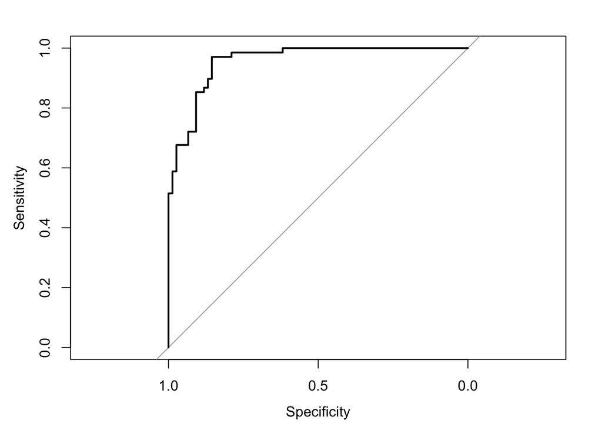

```
## Area under the curve: 0.9567
```

```
##             MeanDecreaseGini
## dist_rivers        18.779398
## dem                14.318347
## dist_coast         10.555929
## mobility            8.283892
## visibility          7.854080
## slope               5.826181
## geology             5.545072
```

```
##       FALSE TRUE class.error
## FALSE    63   13  0.17105263
## TRUE      2   66  0.02941176
```

When testing the model on the full dataset, it is pretty good. This is the percentage of caves that were correctly predicted:

```
## [1] 0.7877934
```

Applying the model to the Ligurian dataset, it predicts accurately the presence of Meso archaeology in the 3 sites with known archaeology from that period. This is satisfying for now.

```
## # A tibble: 221 x 3
##    name                       MesoArch pred
##    <chr>                      <lgl>    <fct>
##  1 Grotta Arene Candide       TRUE     TRUE
##  2 Arma dello Stefanin        TRUE     TRUE
##  3 Arma Veirana               TRUE     TRUE
##  4 Grotta 489                 FALSE    FALSE
##  5 Pozzo dell'Acqua che bolle FALSE    FALSE
##  6 Grotta Adriana             FALSE    FALSE
##  7 Grotta dell'Andrassa       FALSE    FALSE
##  8 Andrassa da Campagna       FALSE    TRUE
##  9 Arma delle Anime           FALSE    TRUE
## 10 Grotta dell'Antenna        FALSE    TRUE
## # … with 211 more rows
```

```
## [1] 65
```

According to this model, these are the sites that we should look into for our surveys:

```
## # A tibble: 65 x 1
##    name
##    <chr>
##  1 Andrassa da Campagna
##  2 Arma Cornarea
##  3 Arma del Sanguineto
##  4 Arma della Moretta
##  5 Arma della Perseveranza
##  6 Arma delle Anime
##  7 Arma delle Fate
##  8 Arma dello Stefanin
##  9 Arma di Perti
## 10 Arma di Ronco
## # … with 55 more rows
```

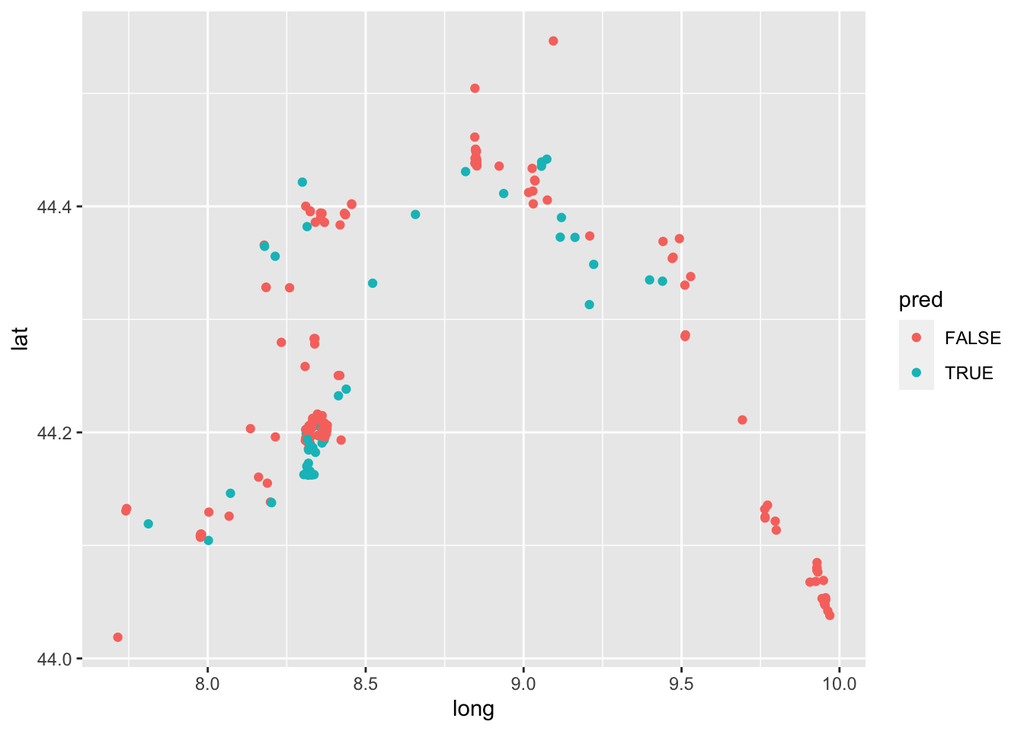

That is a lot of sites, but fortunately, most of them are close to one another. We should expect a fair number of false positives, however.